# Quality Analysis of White Wines by Chemical Make-up by Joe Amlung

This is an exploratory report interested in the quality of different white wines based on their chemical make-up. The data was published by Cortez, et. al. in 2009 in their paper Wine Quality.

# Univariate Plots Section

```
##        X        fixed.acidity    volatile.acidity  citric.acid
##  Min.   :   1   Min.   : 3.800   Min.   :0.0800   Min.   :0.0000
##  1st Qu.:1225   1st Qu.: 6.300   1st Qu.:0.2100   1st Qu.:0.2700
##  Median :2450   Median : 6.800   Median :0.2600   Median :0.3200
##  Mean   :2450   Mean   : 6.855   Mean   :0.2782   Mean   :0.3342
##  3rd Qu.:3674   3rd Qu.: 7.300   3rd Qu.:0.3200   3rd Qu.:0.3900
##  Max.   :4898   Max.   :14.200   Max.   :1.1000   Max.   :1.6600
##  residual.sugar     chlorides       free.sulfur.dioxide
##  Min.   : 0.600   Min.   :0.00900   Min.   :  2.00
##  1st Qu.: 1.700   1st Qu.:0.03600   1st Qu.: 23.00
##  Median : 5.200   Median :0.04300   Median : 34.00
##  Mean   : 6.391   Mean   :0.04577   Mean   : 35.31
##  3rd Qu.: 9.900   3rd Qu.:0.05000   3rd Qu.: 46.00
##  Max.   :65.800   Max.   :0.34600   Max.   :289.00
##  total.sulfur.dioxide    density             pH          sulphates
##  Min.   :  9.0        Min.   :0.9871   Min.   :2.720   Min.   :0.2200
##  1st Qu.:108.0        1st Qu.:0.9917   1st Qu.:3.090   1st Qu.:0.4100
##  Median :134.0        Median :0.9937   Median :3.180   Median :0.4700
##  Mean   :138.4        Mean   :0.9940   Mean   :3.188   Mean   :0.4898
##  3rd Qu.:167.0        3rd Qu.:0.9961   3rd Qu.:3.280   3rd Qu.:0.5500
##  Max.   :440.0        Max.   :1.0390   Max.   :3.820   Max.   :1.0800
##     alcohol         quality
##  Min.   : 8.00   Min.   :3.000
##  1st Qu.: 9.50   1st Qu.:5.000
##  Median :10.40   Median :6.000
##  Mean   :10.51   Mean   :5.878
##  3rd Qu.:11.40   3rd Qu.:6.000
##  Max.   :14.20   Max.   :9.000
```

The summary data shows a much larger range of of values for many of the variables than I would expect. For example, the minimum sulfur dioxide is 9 (mg / dm^3) and the max is 440 (mg / dm^3), I would of initially expected the range to be much smaller.

```
## 'data.frame':    4898 obs. of  13 variables:
##  $ X                   : int  1 2 3 4 5 6 7 8 9 10 ...
##  $ fixed.acidity       : num  7 6.3 8.1 7.2 7.2 8.1 6.2 7 6.3 8.1 ...
##  $ volatile.acidity    : num  0.27 0.3 0.28 0.23 0.23 0.28 0.32 0.27 0.3 0.22 ...
##  $ citric.acid         : num  0.36 0.34 0.4 0.32 0.32 0.4 0.16 0.36 0.34 0.43 ...
##  $ residual.sugar      : num  20.7 1.6 6.9 8.5 8.5 6.9 7 20.7 1.6 1.5 ...
##  $ chlorides           : num  0.045 0.049 0.05 0.058 0.058 0.05 0.045 0.045 0.049 0.044 ...
##  $ free.sulfur.dioxide : num  45 14 30 47 47 30 30 45 14 28 ...
##  $ total.sulfur.dioxide: num  170 132 97 186 186 97 136 170 132 129 ...
##  $ density             : num  1.001 0.994 0.995 0.996 0.996 ...
##  $ pH                  : num  3 3.3 3.26 3.19 3.19 3.26 3.18 3 3.3 3.22 ...
##  $ sulphates           : num  0.45 0.49 0.44 0.4 0.4 0.44 0.47 0.45 0.49 0.45 ...
##  $ alcohol             : num  8.8 9.5 10.1 9.9 9.9 10.1 9.6 8.8 9.5 11 ...
##  $ quality             : int  6 6 6 6 6 6 6 6 6 6 ...
```

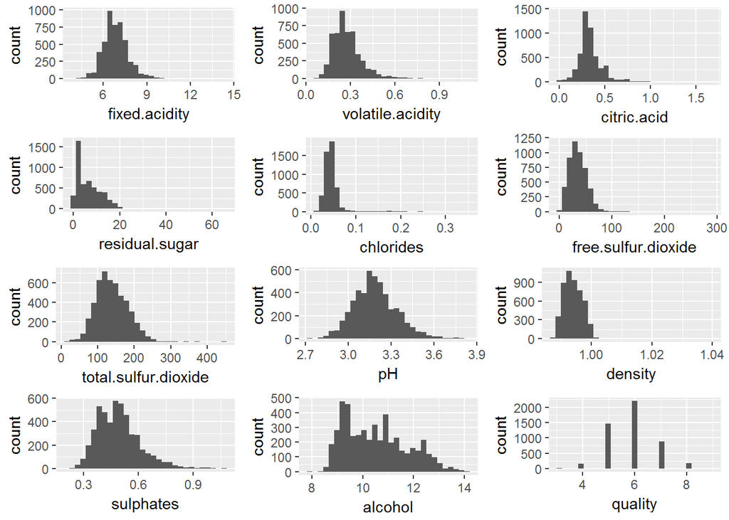

The data, in general, has a fairly normal distribution among the variables, the noted exception being alcohol content. There are some interesting points in the initial graphs through: there is a large spike in residual sugar and sulphates looks like it could have a potential bi-modal distribution.

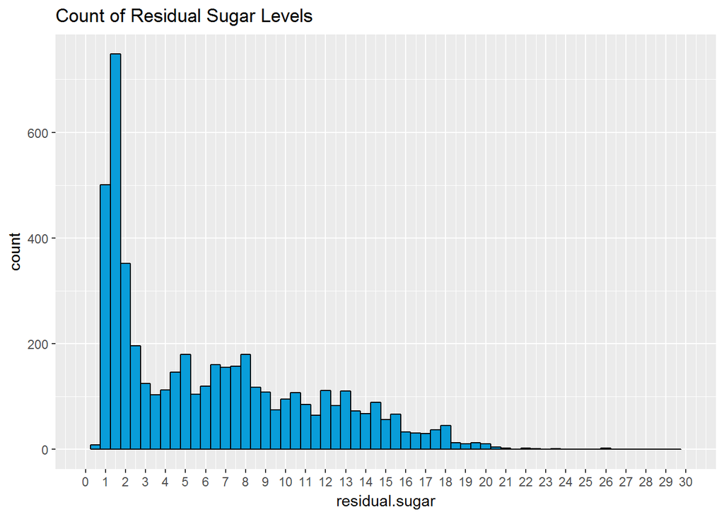

Playing around with the bin widths, the residual sugar content looks like it is actually long-tailed.

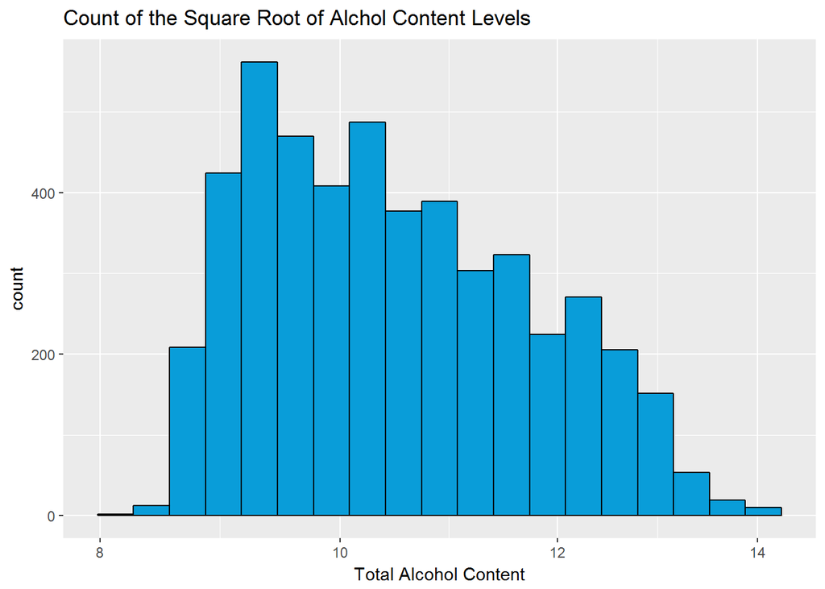

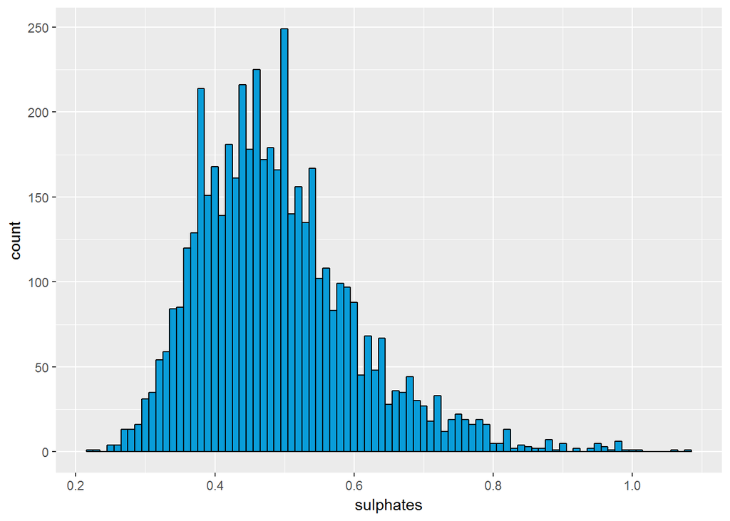

Changing the bin width allows us to see that sulphate content actually has a fairly normal distribution as well, albeit with some outliers

To make the quality data easier to work with, I’m going to split it into 4 categories bases on the quarter percentiles. It should be noted that the distribution isn’t going to be perfect since the bulk of the data has a rating of 6. Another significant digit in quality would of helped this issue significantly.

Now that we can facet wrap or color the variables with the quality class. I’m interested to know if the large spike in the residual sugar plot is from a specific class or not. Here is the same plot shown earlier but with fill set to quality_class

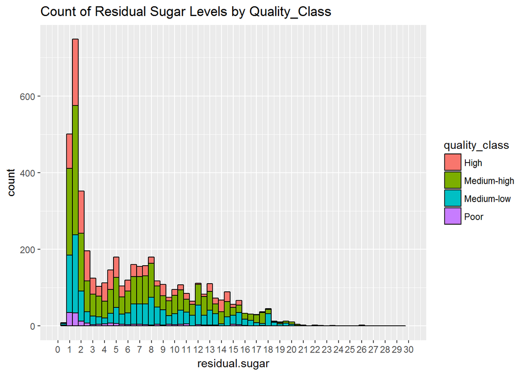

Looks like my hunch of the spike in residual sugar being tied to quality was wrong, looks lie that a variable independent of quality.

# Univariate Analysis

The data set is originally structured with 4898 observations of 12 variables. 11 of those variables are chemical properties related to a specific white wine. One of the more interesting things about this data set is the conformity and the shape of the distribution.

For the most part, there are actually very few outliers. Most of the properties are normally distributed and the tails cut off relatively quickly. This is probably due to wine being unpalatable with extreme chemical properties or it changes the classification of the wine (white to red for example). There were a few noted properties that do not take on a normal distribution: sugar and alcohol content both appear to be long tailed. To obtain the tail for the alcohol content though, a square root transformation was performed to reduce some of the larger spikes in the data set.

My guess is that due to the relative uniformity of the data, that a potential accurate model should be able to be constructed to determine the quality rating of the wine. However, I have heard that wine tastings are very subjective and not scientific, so it will be interesting to see if quality is something that can be modeled. Another thing that would be interesting to check out is how much some of the chemical properties relate to each other. For example, as someone with a chemistry background, I know that larger acid values should lead to a lower pH so I’m curious if that is indeed TRUE or if something is “soaking? them up, leaving the pH unaffected.

A new variable was created, quality_class, which will allow easier interpretation as to whether other variables are having some effect on the quality rating of the wine.

I’m suspecting that many of the variables in this data set are interconnected, making non-univariate plots and analysis very interesting.

# Bivariate Plots Section

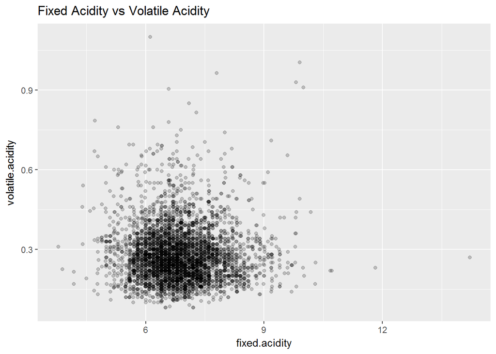

Not really a relation ship between volatile and fixed acidity. I thought that they might be correlated (or inversely correlated).

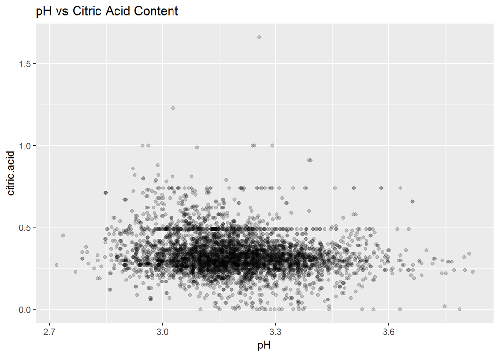

Not what I was expecting. I thought that with increasing citric acid content, the pH should decrease but it appears that there are actually horizontal trends in the data. Now lets check the trend with volatile acidity, pH is a a measure of acidity, so that should show a trend.

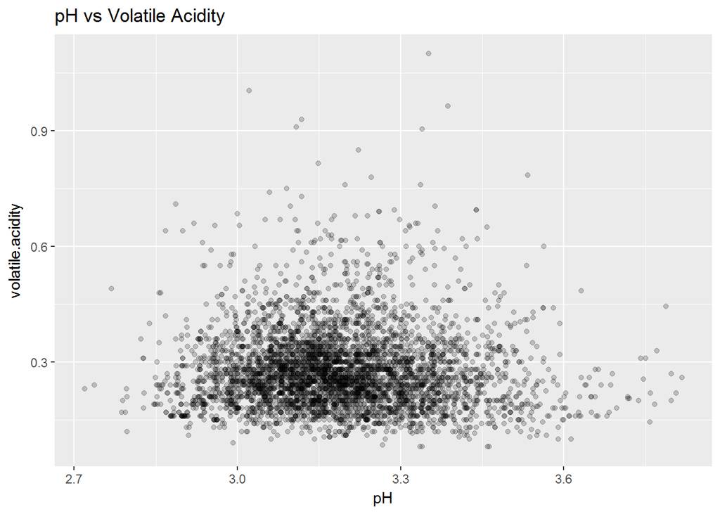

No trend again! Maybe because the acid is volatile it’s already reacted (no longer affecting the pH) and they’re measuring the reacted molecules. To test this, we need to do the same thing with fixed acidity because those chemicals should be fixed (unreacted).

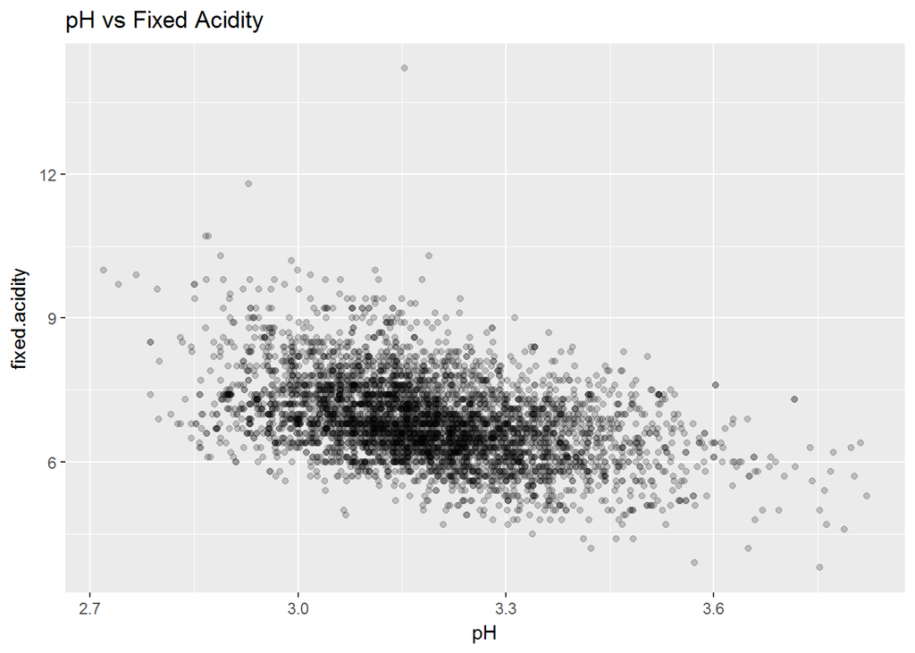

Finally! As you can see there is a definite negative trend with fixed acidity and pH. This makes sense because pH is the measure of free acid molecules and the more there are in the system, the lower the pH. Now I’m curious to see what happens when we color the same plot by quality_class:

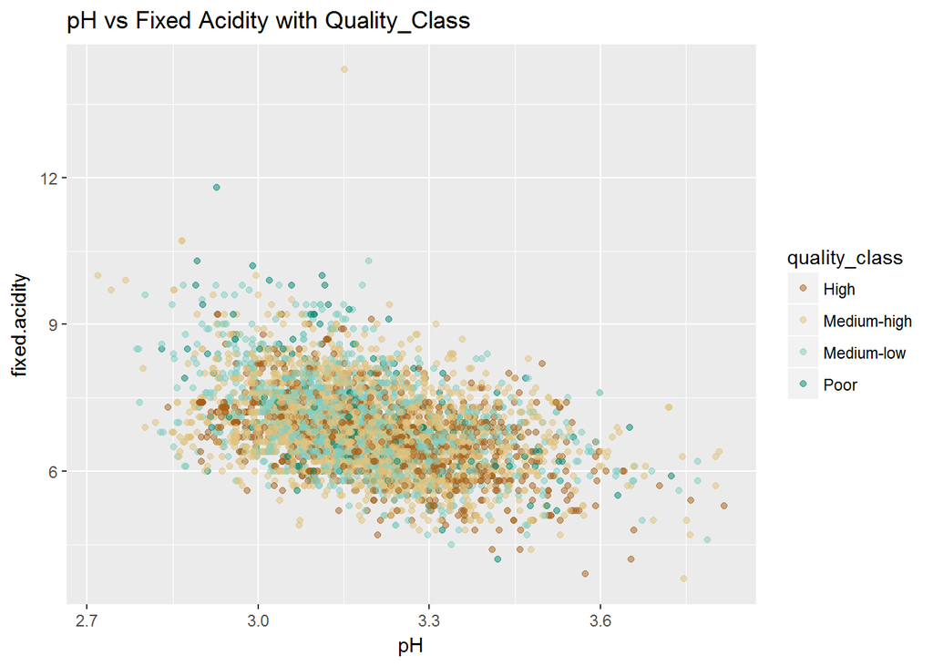

No real relationship between quality and acidity. My goal is to find quality trends so I need to keep exploring. Maybe there is a relationship with sulfates. From now on I’ll also plot quality vs a variable, not quality_class

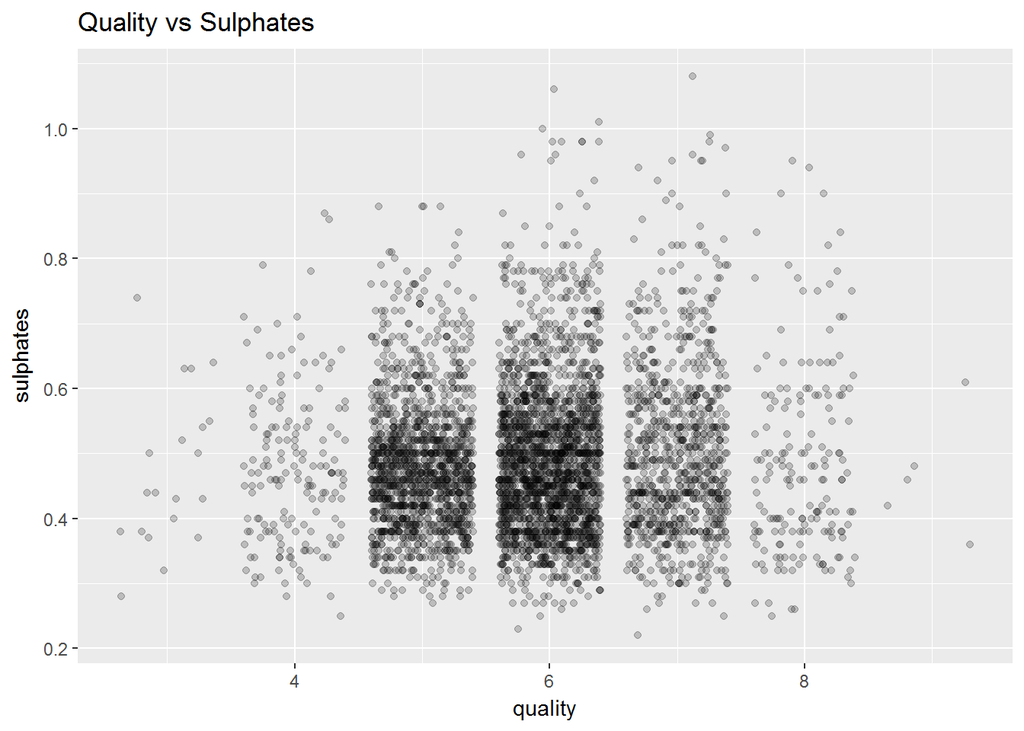

No luck here, lets try free sulfur dioxide

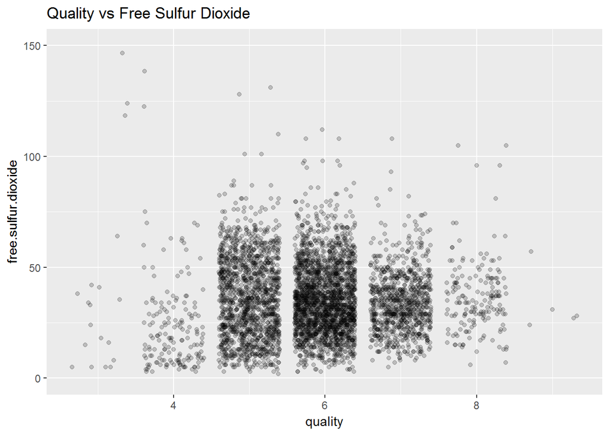

There might be a slight trend here. It looks like higher quality wines might have higher sulfur dioxide contents, we can calculate the r value to give us a better idea.

```
##
##  Pearson's product-moment correlation
##
## data:  winedf$quality and winedf$free.sulfur.dioxide
## t = 0.57085, df = 4896, p-value = 0.5681
## alternative hypothesis: true correlation is not equal to 0
## 95 percent confidence interval:
##  -0.01985292  0.03615626
## sample estimates:
##         cor
## 0.008158067
```

Upon further analysis, it doesn’t look like that has any effect either. I’m starting to wonder if looking at individual chemicals is the wrong was to go about this, maybe total chemical content is what matters? I can check this by adding another column in the df. To make things easier, I’ll only add variables that have the units g / dm ^ 3 (excluding density)

```r
# Below is how the chemical.content variable was constructed
winedf$chemical.content <- winedf$fixed.acidity + winedf$volatile.acidity + winedf$citric.acid + winedf$residual.sugar + winedf$chlorides + winedf$sulphates
```

Now that chemical.content is added, it can be plotted vs quality.

[figure not shown]

Nothing here either. I haven’t checked if alcohol content is related to quality yet, so that is worth checking.

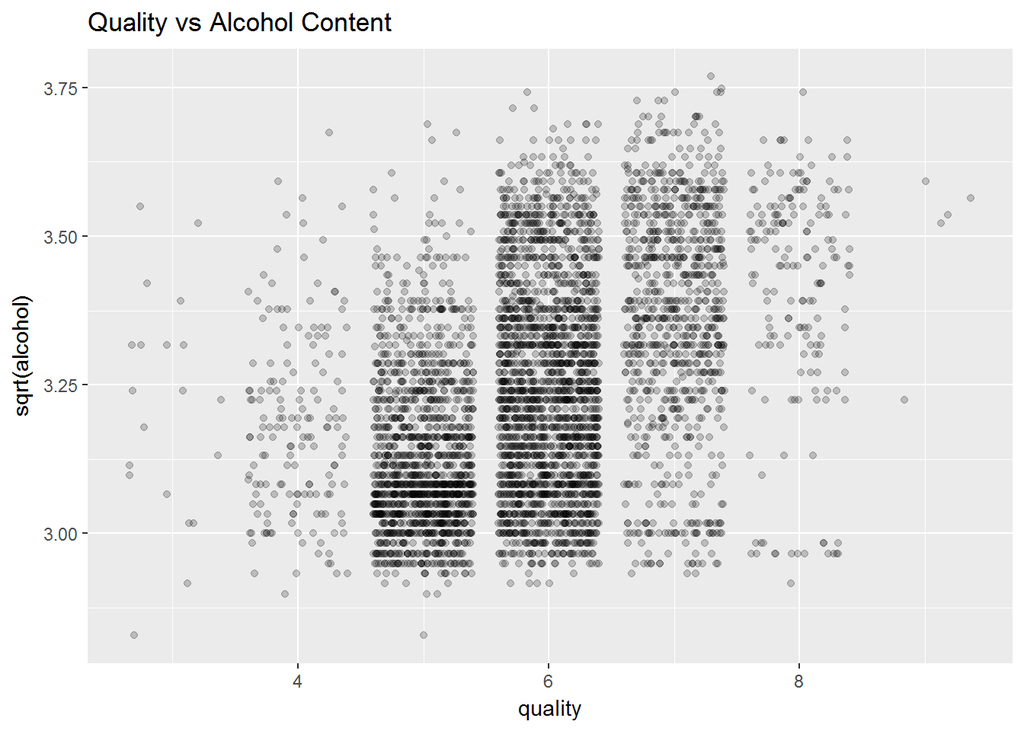

Finally, looks like there’s a correlation here! Now lets check the r value:

```
##
##  Pearson's product-moment correlation
##
## data:  winedf$quality and sqrt(winedf$alcohol)
## t = 33.681, df = 4896, p-value < 2.2e-16
## alternative hypothesis: true correlation is not equal to 0
## 95 percent confidence interval:
##  0.4107026 0.4561855
## sample estimates:
##       cor
## 0.4337203
```

While not the greatest, with a r value of .43, there is some correlation between alcohol and quality. Just a note, this was done on the square root of alcohol to give it more of a normal distribution as was determined in the univarite section.

There hasn’t been any analysis performed on density either so lets look at that next:

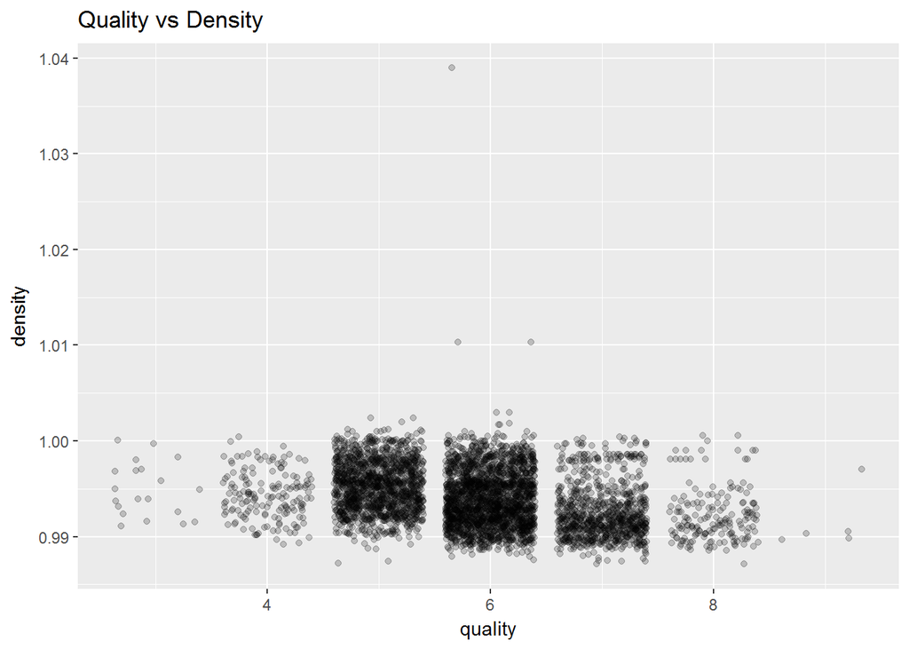

Another trend! Lets look at the r value for that:

```
##
##  Pearson's product-moment correlation
##
## data:  winedf$quality and sqrt(winedf$density)
## t = -22.606, df = 4896, p-value < 2.2e-16
## alternative hypothesis: true correlation is not equal to 0
## 95 percent confidence interval:
##  -0.3325685 -0.2818457
## sample estimates:
##        cor
## -0.3074255
```

Another not so great correlation, but still a correlation.

# Bivariate Analysis

While not exactly what I expected, the pH of the wine is related to fixed acid content, while not the citric or volatile. Without getting to much into the chemistry, this makes sense because checking the variable descriptions we can see that the fixed acidity related to the tartaric acid content and volatile the acetic acid. Then of the three acids: tartaric, citric, and acetic, tartaric is the strongest and has the highest concentration in the wine of the three, it should have the largest effect on the pH.

One of the other surprising things about this data set was the relative lack of trends for the various variables and quality. When I started this investigation I assumed that most of the variables would have a sweet spot where quality was optimized but so far only alcohol content and density really have shown any trends. Which I guess for alcohol isn’t that surprising, inebriated people tend to rate things better than they would while sober so a higher alcohol content might shift peoples perceptions. I’m at a loss for anything related to density though.

I am starting to wonder about how this study was conducted though. Were the already familiar with wines or did they accept anyone into the study? Then, was it one wine per participant? Or were they given multiple wines in one sitting? I could imagine that there would be a bias for either the initial or final tastings if this is the case.

Anyways, hopefully with the addition of more variables we can start to see definite trends so we can build a more accurate model.

# Multivariate Plots Section

I’m interested in why a lower density makes for better wine. I know chemical_content should be related to density, so lets look at those two while coloring by quality

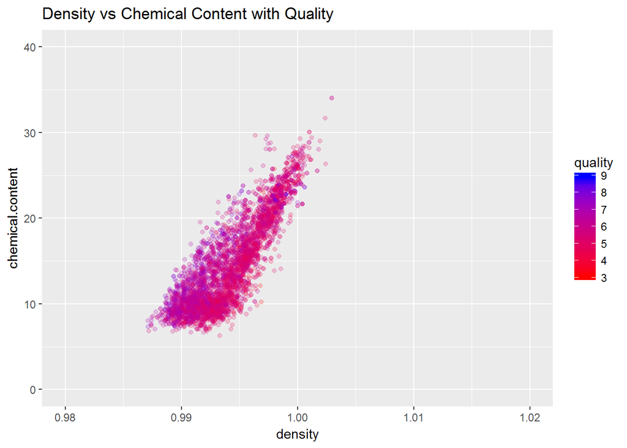

This implies that there is a sweet spot with density and chemical content. The above plot suggests that having a low overall density with a high chemical content might produce higher quality wine.

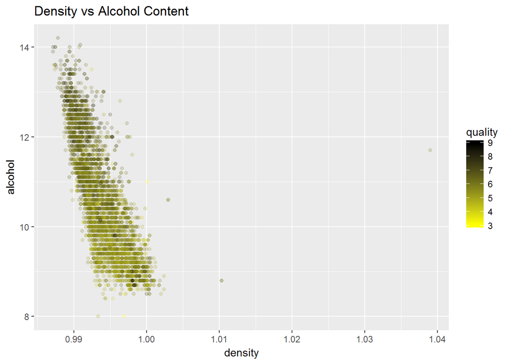

The above plot shows density vs alcohol coloring with quality. Being the variables that map a trend, I hoped that something would show here but if there is a trend it is very weak.

Some plots that have not been explored are the quality vs the ratio of interconnected variables.

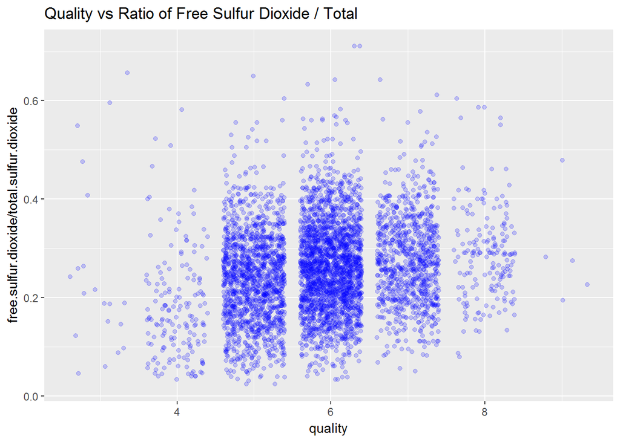

```
##
##  Pearson's product-moment correlation
##
## data:  winedf$quality and winedf$ratio.sulfur
## t = 14.076, df = 4896, p-value < 2.2e-16
## alternative hypothesis: true correlation is not equal to 0
## 95 percent confidence interval:
##  0.1701474 0.2239834
## sample estimates:
##       cor
## 0.1972141
```

Small correlation

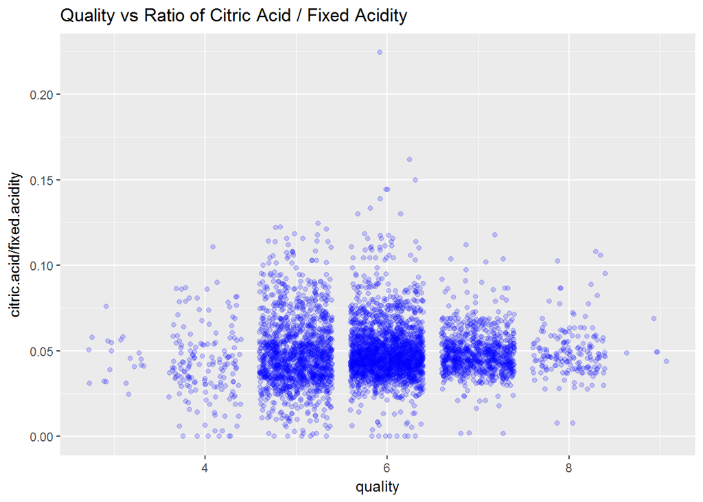

No correlation.

Now that we have a few correlations, even though they aren’t the strongest, I’ll try and make a model.

```r
m1 <- lm(I(quality) ~ I(alcohol^(1/2)), data = winedf)
m2 <- update(m1, ~ . + density)
m3 <- update(m2, ~ . + (free.sulfur.dioxide/total.sulfur.dioxide))
mtable(m1, m2, m3, sdigits = 3)
```

```
##
## Calls:
## m1: lm(formula = I(quality) ~ I(alcohol^(1/2)), data = winedf)
## m2: lm(formula = I(quality) ~ I(alcohol^(1/2)) + density, data = winedf)
## m3: lm(formula = I(quality) ~ I(alcohol^(1/2)) + density + free.sulfur.dioxide +
##     free.sulfur.dioxide:total.sulfur.dioxide, data = winedf)
##
## =================================================================================
##                                                  m1          m2          m3
## ---------------------------------------------------------------------------------
##   (Intercept)                                 -0.742***  -26.548***  -29.939***
##                                               (0.197)     (6.337)     (6.285)
##   I(alcohol^(1/2))                             2.045***    2.356***    2.308***
##                                               (0.061)     (0.097)     (0.095)
##   density                                                 24.947***   28.088***
##                                                           (6.123)     (6.089)
##   free.sulfur.dioxide                                                  0.027***
##                                                                       (0.002)
##   free.sulfur.dioxide x total.sulfur.dioxide                          -0.000***
##                                                                       (0.000)
## ---------------------------------------------------------------------------------
##   R-squared                                       0.188      0.191       0.236
##   adj. R-squared                                  0.188      0.191       0.235
##   sigma                                           0.798      0.797       0.775
##   F                                            1134.398    577.306     377.203
##   p                                               0.000      0.000       0.000
##   Log-likelihood                              -5844.259  -5835.967   -5696.386
##   Deviance                                     3118.449   3107.909    2935.725
##   AIC                                         11694.517  11679.935   11404.771
##   BIC                                         11714.007  11705.921   11443.750
##   N                                            4898       4898        4898
## =================================================================================
```

And as we can see, our model is a failure. Our model only has a .236 R-squared value.

# Multivariate Analysis

The multivariate analysis began to reveal a few more trends. As you can see from the Density vs Chemical with Quality plot, there is a sweet spot were quality is maximized. While this trend doesn’t hold true for all of the variables, I would hypothesize that these are the sorts of areas that would need to be explored if this was a larger study.

# Final Plots and Summary

### Plot One

[figure not shown]

### Description One

I like this plot because it gives us some confidence in the chemical data. I especially wanted to do this because we weren’t able to get great correlations with quality so any checks on the base data gives us confidence that our results aren’t based on faulty data. Then as mentioned earlier, I have a background in Chemistry, so I know pH and acid content should be related. This plot clearly shows that there is a negative relationship between pH and fixed acidity which should be the case.

### Plot Two

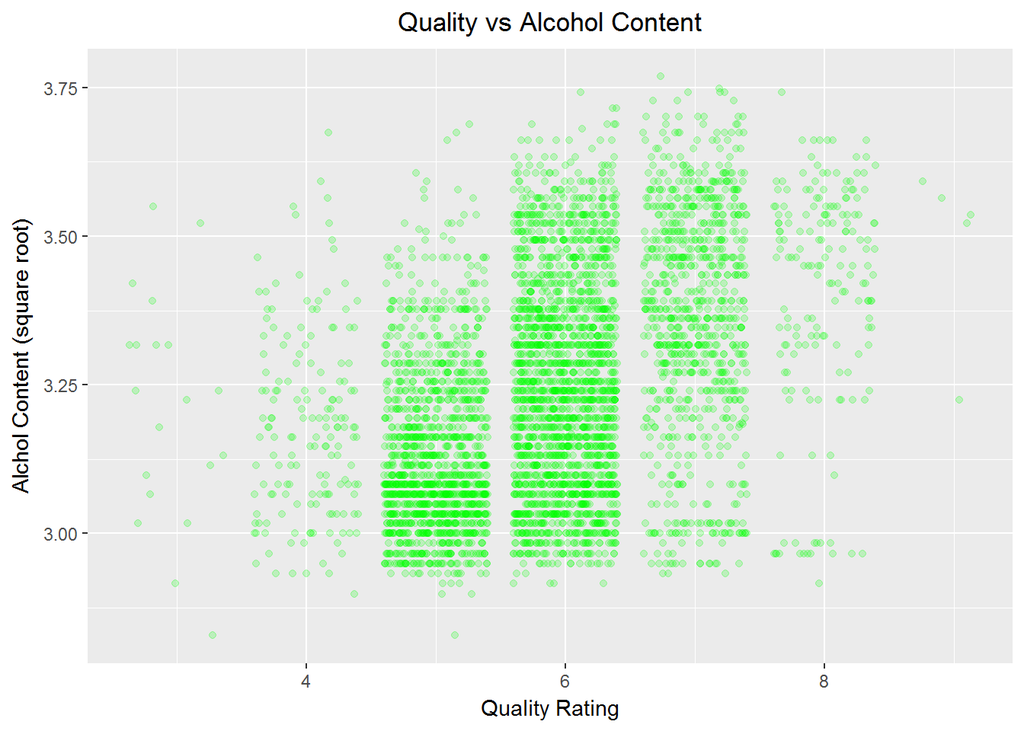

### Description Two

This plot shows the best correlation that we were able to achieve. You can clearly see that as the alcohol content of the wine increases, that it raises the average rating of the wine. While still not the greatest correlation, it shows us that the potential for building a model does exist.

### Plot Three

[figure not shown]

### Description Three

This plot is included because it shows the another avenue of interest for modeling this data. You can obviously see that there are certain region of the plot that have a higher likely hood of being favorably rated. So go forward, to model this data set, plots like this would argue that a linear approach to modeling might not be the best course of action and some other more advanced technique that is outside the scope of this course should be used.

# Reflection

While this exploration didn’t reach its initial goal of formulating a solid model for wine quality, quite a few insights were made. For one, we found that some trends do exist in the data for both the chemical content and how they relate to the quality rating. However, there are some inherent problems with this data set that will need to be addressed in any future studies.

One of those problems is the subjective nature wine. There really isn’t a standard to say what’s good and what isn’t. According to the data set notes, they used ‘experts’ to determine the quality rating. While that’s nice in theory, one expert could have an entirely different palate then the other, leading to a lack of cohesion in what is considered good or bad. And then with something as subjective as taste, there are psychological effects that have huge affect on the perceived taste, even something as small as the glass it’s served in can affect how the drinker perceives the taste. Then we don’t know if the study controlled for things like this. So this a major area of concern and for future studies it would be great to conduct it in in such a way that these concerns are minimized like a standard for how things are scored.

Then the other problem with the data is how the ratings are dispersed. If you look at the histogram of quality data, you’ll see that it is pretty close to A bell curve. While that’s nice for regression analysis, it leaves us without a lot of of information to to determine what constitutes a good wine. Instead the bulk of our data has a rating of 5 or 6 and that doesn’t leave us a large enough range to determine if certain parameters are improving the quality rating or not, our error is too high. One thing that would be a big help for the analysis of this data set would be an addition of another significant figure to the quality rating. That way we might be able to see minor trends in the quality rating and letting us build a model around those trends.

Overall though, I’m happy with this conclusions we’ve reached with this report. I think this a great building block for a machine learning exercise and after completing Udacity’s machine learning course, I plan to come back and apply those concepts to make a better model for predicting quality.